# Teste de conhecimento Cinnecta

Claudio Resende

09/10/2020

# Introdução

Este documento apresenta uma análise descritiva e preditiva de dados de acomodações do AirBnB. A base de dados fornecida contém 34 variáveis (colunas) e 7146 observações (linhas).

Para a análise aqui realizada foram selecionadas 22 colunas: foram excluídas colunas identificadoras da acomodação, como latitude e longitude, e as colunas *booleanas* relacionadas às avaliações (colunas ’_na’).

A primeira parte da análise consiste em explorar as variáveis para identificar eventuais padrões, tendências, vieses e outros tipos de comportamento dos dados que possam requerer transformações. Em seguida, são propostos modelos estatísticos para analisar a relação entre as variáveis.

## Análise descritiva/exploratória

A seguir as variáveis da base de dados são analisadas individualmente e, em seguinda, em combinação com uma ou duas outras variáveis.

#### Anfitrião

O tipo de anfitrião é uma variável importante nos serviços oferecidos pelo AirBnB porque indicam o nível de experiência do anfitrião e a qualidade do serviço prestado. A base de dados analisada está distribuída em 59% e 41% para anfitriões comuns (host) e superanfitriões (superhost), respectivamente.

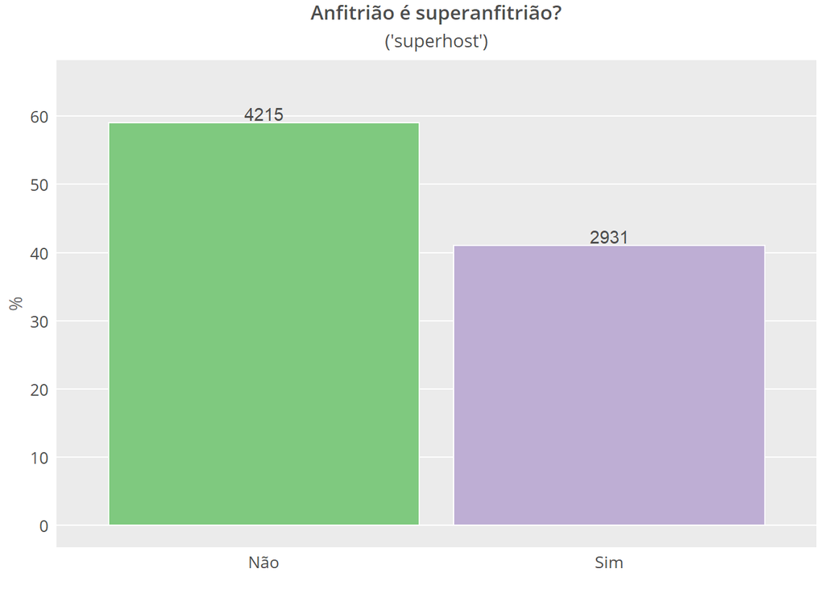

#### Políticas de cancelamento

O tipo de política de cancelamento possui uma distribuição mais concentrada. O AirBnB oferece seis tipos de política para o anfitrião escolher. Entre os dados disponinilizados, três categorias somam 98,3% dos casos: flexível, moderada e longa duração. Como poderá ser visto adiante, essas políticas se relacionam com o tipo de acomodação oferecida. Por exemplo, acomodações completas são propícias para estadias longas, ao passo que estadias simples, como quartos, são ideais para estadias curtas de poucos dias.

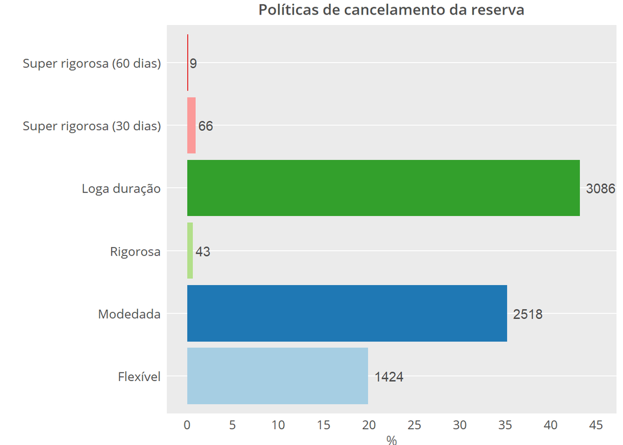

#### Tipos de acomodação

Lugares inteiros são a maioria das ofertas presentes na base de dados 61.1%, seguido de quartos inteiros 36.4%. Quartos compartilhados são apenas 2.5%.

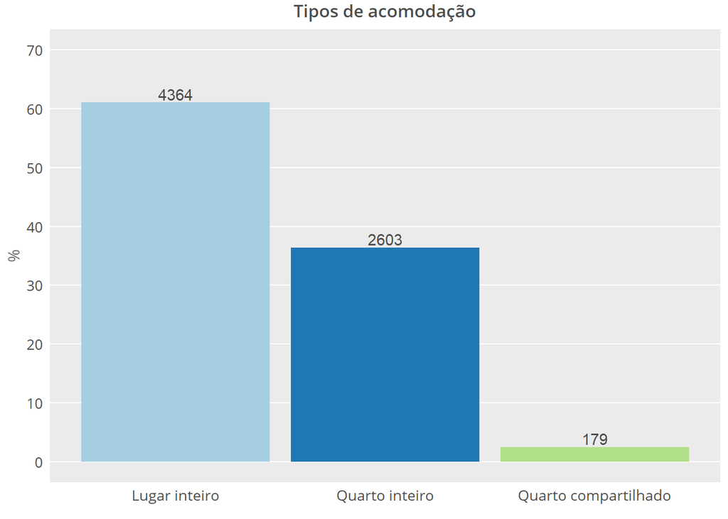

Quartos compartilhados, pela sua natureza, além de serem minoria na base, são também os mais permissivos quanto à política de cancelamento.

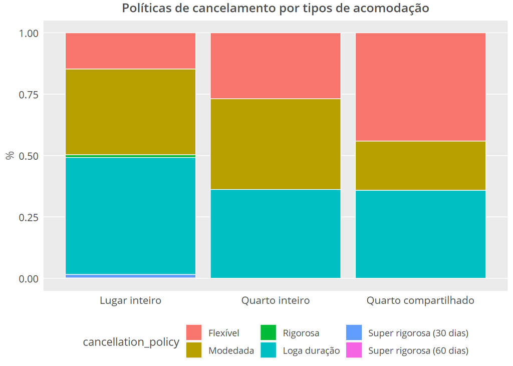

#### Mínimo de noites

Outra variável intrinsecamente relacionada com o tipo de acomodação é o número mínimo de noites que o hóspede deve contratar o serviço. Como pode ser visto no boxplot abaixo, 75% das acomodações exigem até 30 dias de tempo mínimo, sendo que a mediana é de quatro dias.

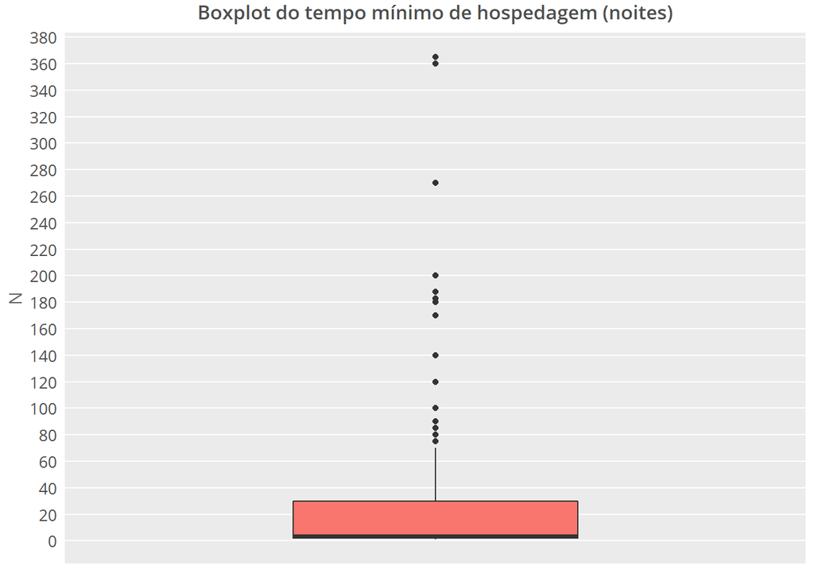

## Infraestrutura da hospedagem

Os dados de infraestrutura também são importantes para avaliar as diferenças entre as acomodações oferecidas. Uma das variáveis disponíveis, tipo de cama (`dados$bed_type`), varia pouco (99% das camas são do tipo ‘cama de verdade’, ou ‘real bed’), e portanto não será considerada na análise.

Por outro lado, os números de cômodos (banheiros e quartos) e de camas, bem como o número máximo de hóspedes, variam entre as hospedagens. O boxplot abaixo apresenta a distribuição de cada uma dessas variáveis: é possível perceber que há uma concentração em valores pequenos e a presença de *outliers*.

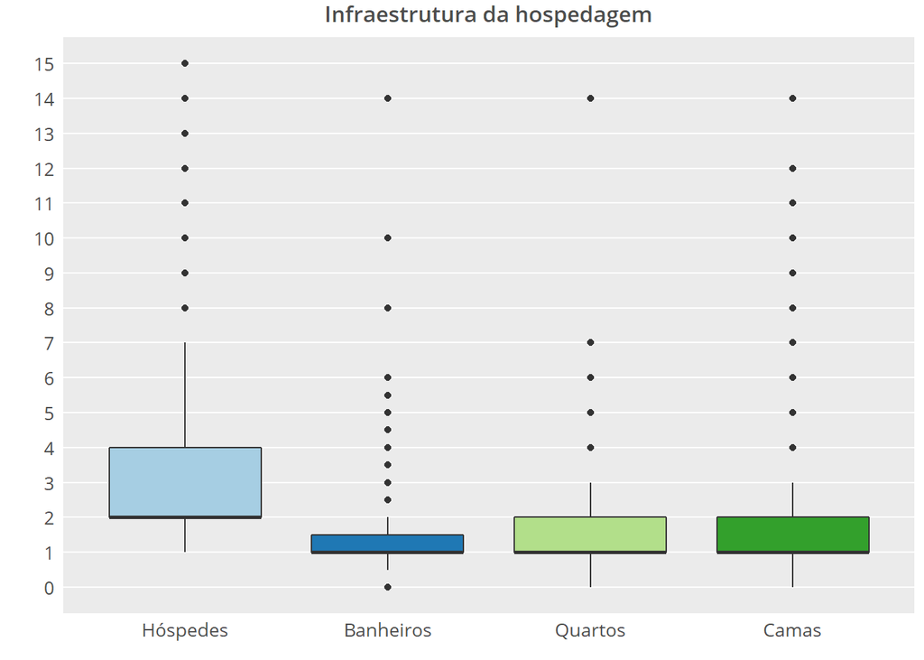

### Avaliações

O número total de avaliações por hospedagem, o valor final da avaliação e valores das avaliações por item também possuem uma forte concentração: a maioria das hospedagens possui poucas ou nenhuma avaliação, e são também, em sua maioria, muito bem avaliadas (médias acima de 9,5), conforme pode ser visto nos histogramas abaixo.

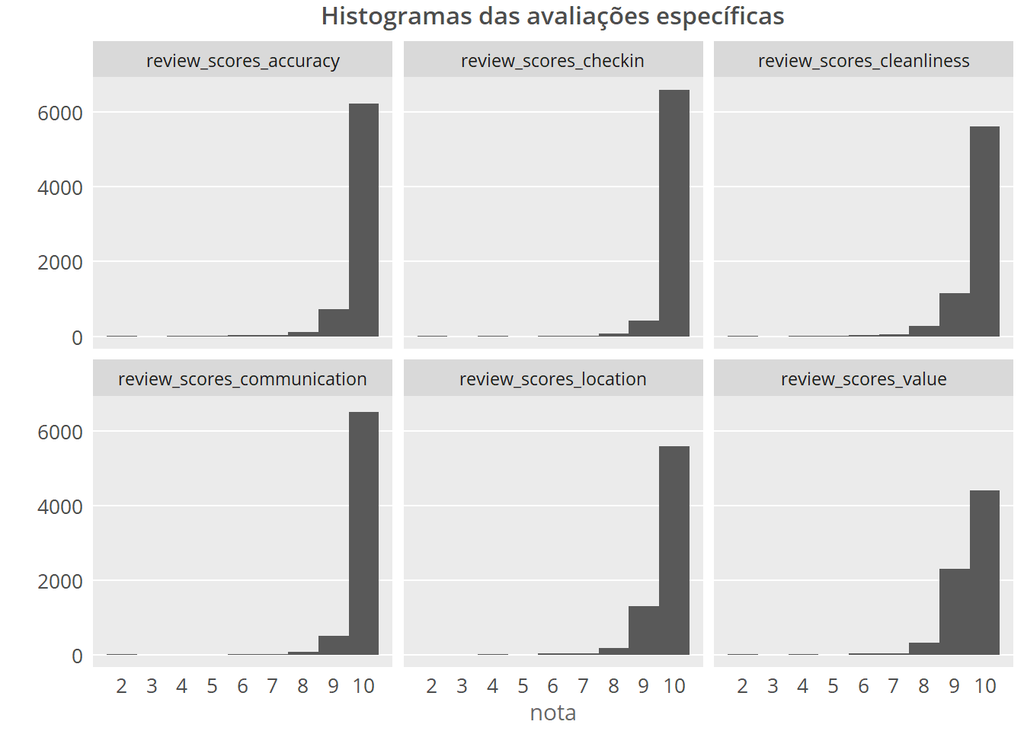

A maioria das hospedagens possui poucas avaliações: a média é de 43.6 avaliações e a mediana é de 11. O histograma e o boxplot abaixo mostram essa concentração e permitem verificar também que há *outliers* na variável

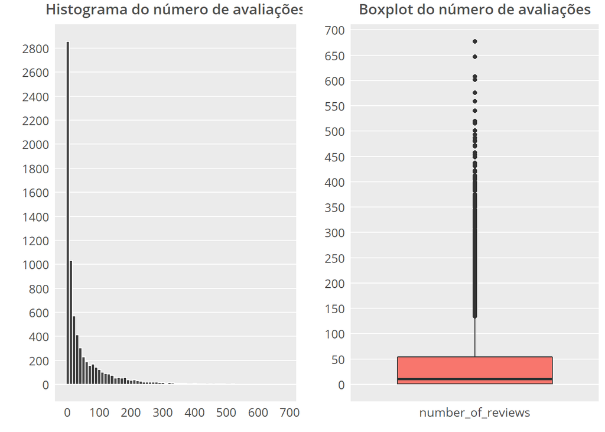

Comportamento semelhante aos dos preços praticados. O valor médio das hospedagens é U$213.3, mas há hospedagens que cobram U$10.000.

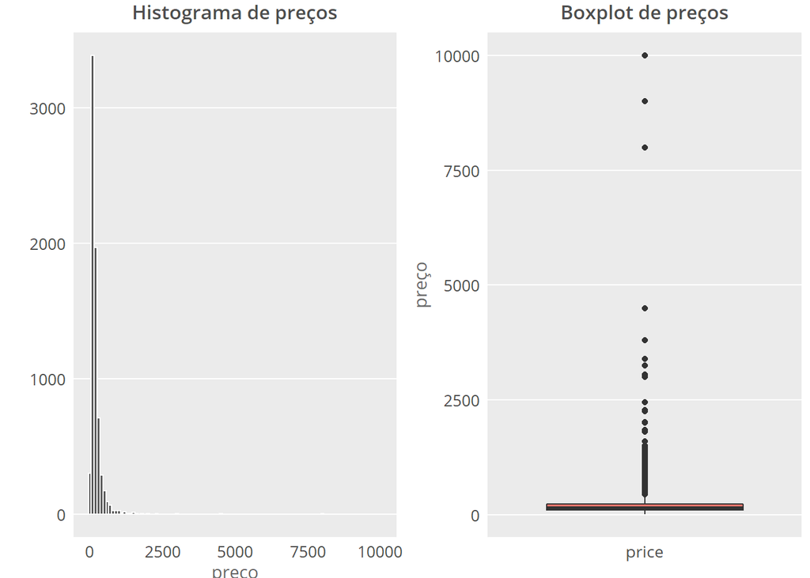

## O que diferencia ‘Superhosts’ dos anfitriões comuns?

As análises a seguir sugerem que superhosts possuem mais e melhores avaliações do que anfitriões comuns.

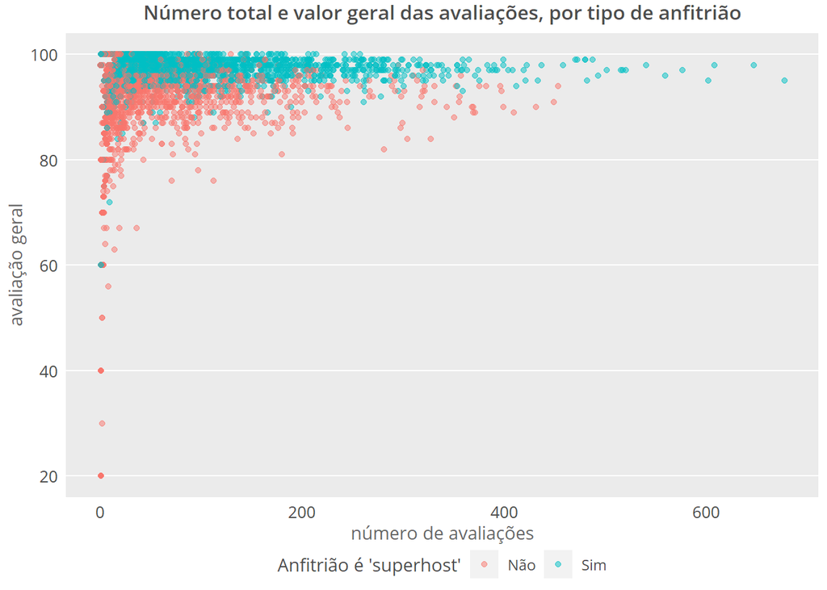

Como como pode ser visto a seguir, a maioria dos superhosts pratica preços abaixo da média (U$213.3).

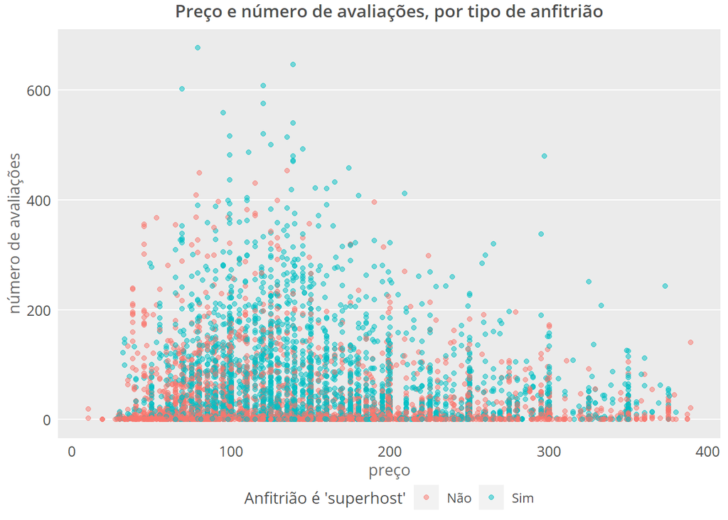

## Avaliações e preços

As hospedagens com maior número de avaliações são aquelas com menor preço. Ao mesmo tempo, as hospedagens com avaliações mais baixas são majoritariamente as mais baratas.

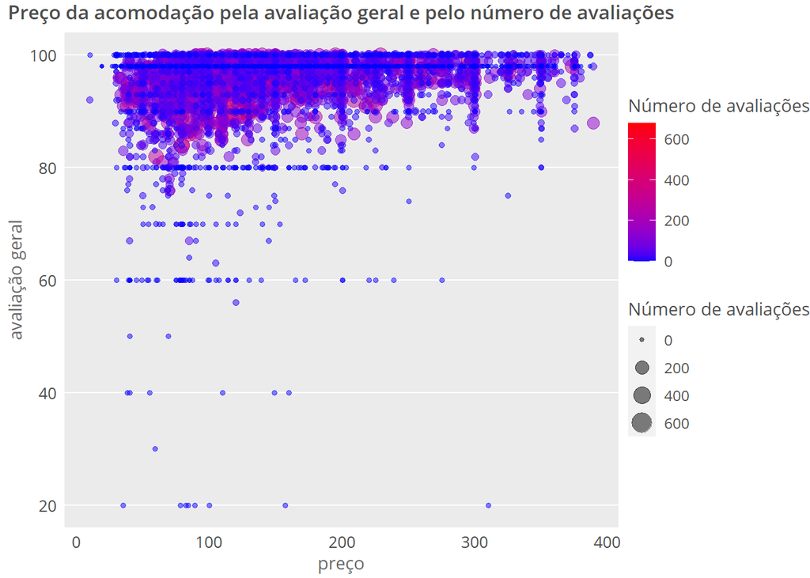

# Predição

Sabendo como as variáveis se comportam, de maneira geral, podemos agora empreender uma análise preditiva. Proponho aqui dois modelos gerais:  
*Avaliação geral como variável dependente (resposta);* Preço como variável dependente (resposta).

```r
summary(modelo2)
```

```
##
## Call:
## lm(formula = review_scores_rating ~ price + host_is_superhost +
##     room_type + bathrooms + bedrooms + beds + minimum_nights +
##     number_of_reviews, data = modelo)
##
## Residuals:
##     Min      1Q  Median      3Q     Max
## -75.347  -1.016   1.435   2.970  11.130
##
## Coefficients:
##                         Estimate Std. Error t value Pr(>|t|)
## (Intercept)           95.7160938  0.2159045 443.326  < 2e-16 ***
## price                  0.0010514  0.0002521   4.171 3.07e-05 ***
## host_is_superhost1     2.5336791  0.1546655  16.382  < 2e-16 ***
## room_typePrivate room -0.7540517  0.1663220  -4.534 5.89e-06 ***
## room_typeShared room  -0.5553824  0.4908922  -1.131 0.257936
## bathrooms             -0.3815666  0.1046278  -3.647 0.000267 ***
## bedrooms               0.8281040  0.1219552   6.790 1.21e-11 ***
## beds                  -0.3942144  0.0937858  -4.203 2.66e-05 ***
## minimum_nights        -0.0193460  0.0033923  -5.703 1.23e-08 ***
## number_of_reviews     -0.0059757  0.0010713  -5.578 2.52e-08 ***
## ---
## Signif. codes:  0 '***' 0.001 '**' 0.01 '*' 0.05 '.' 0.1 ' ' 1
##
## Residual standard error: 6.091 on 7136 degrees of freedom
## Multiple R-squared:  0.06237,    Adjusted R-squared:  0.06119
## F-statistic: 52.74 on 9 and 7136 DF,  p-value: < 2.2e-16
```

O segundo modelo geral proposto foi construído para predizer o preço do imóvel a partir das demais variáveis. Como feito anteriormente, primeiro gerou-se um modelo com todas as variáveis para determinar quais possuem significância. A seguir, apresenta-se o resultado do modelo com as variáveis ‘review_scores_rating’, ‘room_type’, ‘accommodates’, ‘bathrooms’, ‘bedrooms’, ‘minimum_nights’ e ‘number_of_reviews’.

O modelo indica que acomodações de tipo ‘quarto privado’ e ‘quarto compartilhado’ são mais baratas que acomodações de tipo ‘lugar inteiro’ (coeficiente negativo). O mesmo ocorre com o número mínimo de noites e com o número de avaliações.

Por outro lado, os preços tendem a subir quanto maiores forem as notas, o número máximo de hóspedes, de banheiros e de quartos. Naturalmente, locais maiores tendem a ser mais caros (o que é esperado), da mesma forma que os locais mais bem avaliados tendem a ser mais procurados, o que contribui para elevar os preços.

Esse modelo possui uma capacidade explicativa razoável. O R2 ajustado de 0,1677 indica que o modelo explica 16,7% das variações de preços.

```r
summary(modelo4)
```

```
##
## Call:
## lm(formula = price ~ review_scores_rating + room_type + accommodates +
##     bathrooms + bedrooms + minimum_nights + number_of_reviews,
##     data = modelo)
##
## Residuals:
##     Min      1Q  Median      3Q     Max
## -1369.8   -70.6   -23.7    26.5  9636.1
##
## Coefficients:
##                         Estimate Std. Error t value Pr(>|t|)
## (Intercept)           -165.61599   53.34521  -3.105 0.001913 **
## review_scores_rating     2.32465    0.54080   4.299 1.74e-05 ***
## room_typePrivate room  -51.71239    8.04317  -6.429 1.36e-10 ***
## room_typeShared room  -129.38596   22.82057  -5.670 1.49e-08 ***
## accommodates            30.42277    2.86360  10.624  < 2e-16 ***
## bathrooms               22.33345    4.87963   4.577 4.80e-06 ***
## bedrooms                52.74687    5.73288   9.201  < 2e-16 ***
## minimum_nights          -0.59114    0.15835  -3.733 0.000191 ***
## number_of_reviews       -0.24710    0.04817  -5.130 2.97e-07 ***
## ---
## Signif. codes:  0 '***' 0.001 '**' 0.01 '*' 0.05 '.' 0.1 ' ' 1
##
## Residual standard error: 284.1 on 7137 degrees of freedom
## Multiple R-squared:  0.1687, Adjusted R-squared:  0.1677
## F-statistic:   181 on 8 and 7137 DF,  p-value: < 2.2e-16
```

```r
modelo %>% select(price, predito_modelo4) %>% head(15)
```

```
##     price predito_modelo4
##  1:   170       181.15364
##  2:   235       296.97783
##  3:    65       160.07569
##  4:    65       180.89680
##  5:   785       340.17282
##  6:   255       345.12361
##  7:   139        16.36843
##  8:   135        24.58520
##  9:   265       287.06736
## 10:   177       286.24301
## 11:   194       379.75468
## 12:   139       172.91504
## 13:    85       151.17059
## 14:    85        91.88988
## 15:    79        17.84628
```

# Conclusões

Os modelos propostos não foram capazes de explicar as variações das avaliações gerais e dos preços das hospedagens. Seria preciso pensar outros modelos, com diferentes combinações de variáveis, para investigar se é possível predizer os valores de avaliação e preço a partir das variáveis presentes na base ou se seria necessário obter outras variáveis para isso.